# Illicit drug price indices

Nick Janetos

2015-06-18

# Introduction

This document describes the process with which I construct price indices using microdata scraped from various ‘Deep Web’ illicit drug marketplaces.

## Data

Connect directly to the SQL database containing the microdata using `connect`, and connecting to `drugs_all`, which contains the complete set of data. There are two relevant fields in `drugs_all`: `Listing` and `Listing_prices`. The field `Listing` contains a complete set of all listings that were scraped, while `Listing_prices` contains a complete set of all prices that were scraped. For example, someone may have offered Ecstasy for sale under the heading ‘200mg XTC 10x TOP QUALITY’ during the months of January and Febuary, during which the site was scraped 8 times. Then there will be a corresponding single entry under `Listing`, and 8 entries under `Listing_prices`, one for each time the price of the listing was recorded.

To begin with, let’s construct a price index for the drug Ecstasy on the marketplace Agora. Ecstasy is one of the easiest drugs to track, because it has a relatively standard name (either ‘mdma’, ‘ecstasy’, or, often, ‘xtc’), a universally accepted unit of measurement, milligrams, and is a relatively homogeneous good. It is coded as `MDMA` in the scraper’s codebook, but the category is encoded as a hash of the string name, which in this case is 2361707. The prices of some entries are recorded in bitcoin. I exclude those entries because it is a pain to convert from bitcoins to US dollars. Almost all entries for Ecstasy are measured in milligrams, and entries measured in grams are probably miscategorized, so we only select entries measured in milligrams. Our query therefore looks like

```r
# Query all listings + associated prices which belong to category
# 2361707 (MDMA), are denominated in dollars, and are measured in mg.

select.database("drugs_agora");
price_mdma <- get.query("SELECT * FROM Listing L
                            INNER JOIN Listing_prices P
                            ON L.id = P.Listing_id
                            WHERE category = 2361707
                            AND denomination = 'USD'
                            AND units = 'mg'");
```

Listings are listed in all sorts of quantities. The column `mult` in the data encodes how much each unit of the good listed measured, and `amount` encodes the total number of those units that were offered. For example, the listing ‘10x XTC 220mg’ should result in `mult = 220`, `units = mg`, and `amount = 10`. So, let’s normalize units:

```r
price_mdma$normalized = price_mdma$price / (price_mdma$mult * price_mdma$amount);
```

Let’s begin by looking at a raw plot of prices at various points in time.

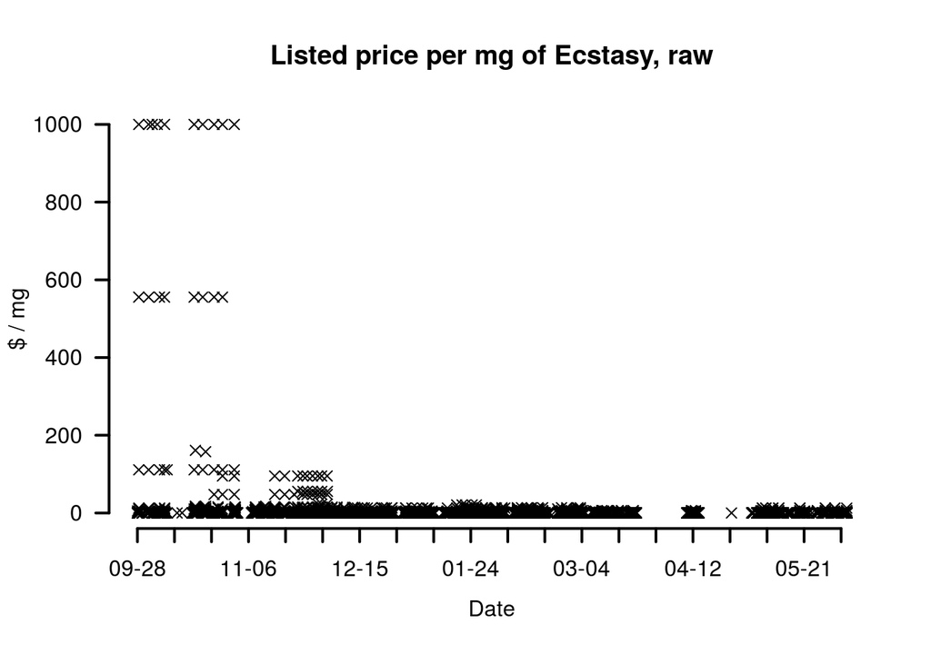

Notice that there are many extreme outliers. This is an unfortunate consequence of the fact that many deep web markets lack some crucial features, in this case, the ability for a seller to ‘deactivate’ a listing. As a result, many sellers who run out of inventory, but are unwilling to delete their listing because they expect to be in business soon, will simply take the offered price and add zeros to the end to avoid making sales.

Now, let’s look at a density map for the distribution of prices over time. The following two graphs split listings into ‘small’ listings and ‘large’ listings. Large listings are listings for large numbers of ecstasy pills. Presumably, they are intended for resale. Small listings are everything else.

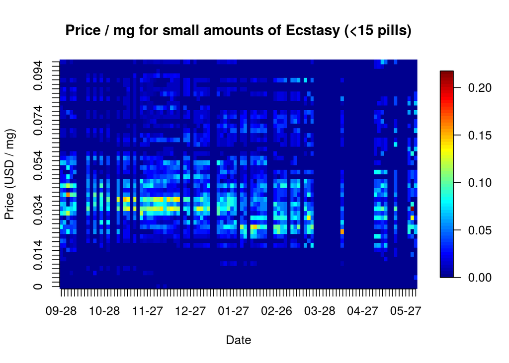

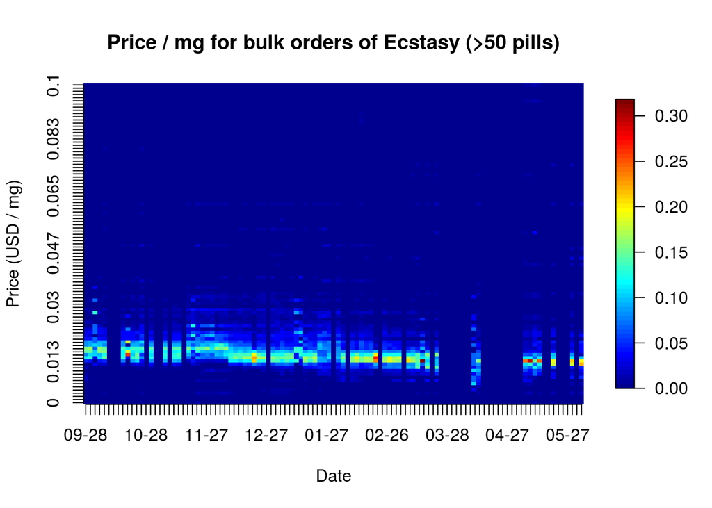

The features to notice are the following: First, there are some dates for which no data were collected. This is a consequence of the fact that these markets are often offline. Second, there is clear evidence of a quantity discount. Third, the data for small listings are quite noisy, while the data for large listings are less noisy. One can imagine any number of explanations for this, the most obvious being that the denominator for the normalized price of large listings is larger, another being that bulk listings are intended for professionals who have a better sense of price.

To construct price indices, the data are binned into groups of 1000 listings each, and then I plot the median. This is done using `construct.index`, and `plot.index` produces the plots.

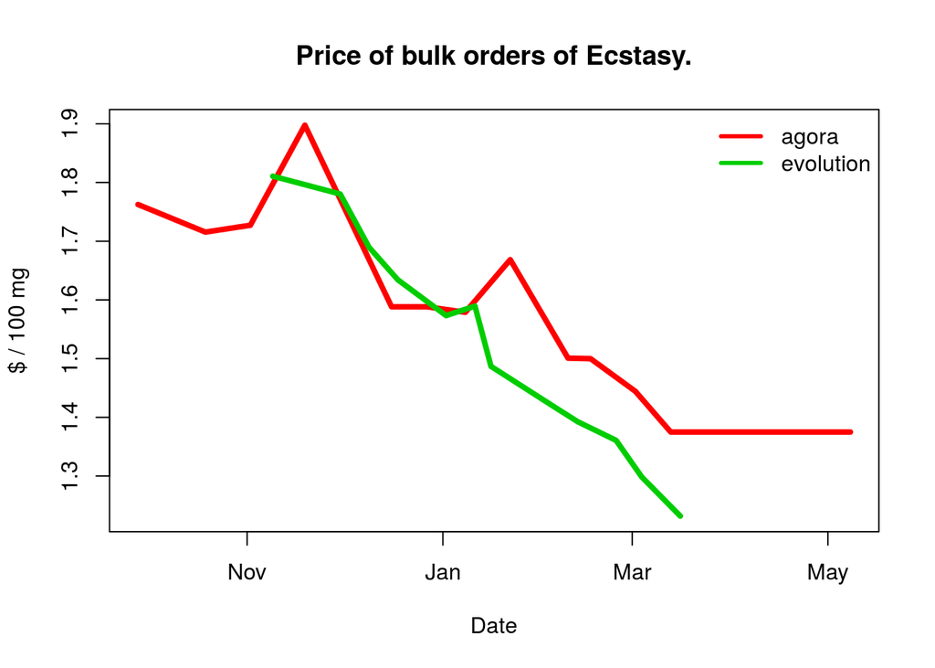

```r
plot.index(market = c("agora", "evolution"),
           category = "2361707",
           units = "mg",
           additionalQuery = "amount > 50",
           binsize = 1000,
           scale = 100)
title("Price of bulk orders of Ecstasy.")
```

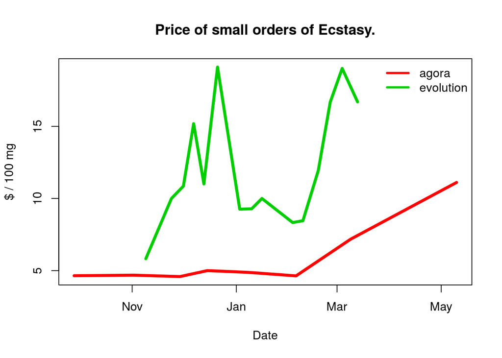

```r
plot.index(market = c("agora", "evolution"),
       category = "2361707",
       units = "mg",
       additionalQuery = "amount < 20",
       binsize = 1000,
       scale = 100)
title("Price of small orders of Ecstasy.")
```

The plots split prices into bulk and small listings.